# Atividade Flor de Iris

Luciana Sousa Martins

# Distribuiçao Normal Multivariada

*A distribuição normal multivariada, também conhecida como distribuição gaussiana multivariada, é uma generalização da distribuição normal univariada para múltiplas variáveis aleatórias correlacionadas entre si. Em vez de lidar com uma única variável aleatória, como na distribuição normal univariada, a distribuição normal multivariada descreve conjuntamente múltiplas variáveis aleatórias que estão distribuídas normalmente.*

```r
# limpar todas as variáveis

rm(list = ls(all.names = TRUE))
```

```r
# biblioteca

library(ellipse)
```

```r
library(MASS)
library(xtable)
library(corrplot)
library(knitr)
library(stats)
```

```r
file.save <-"C:/Users/Luciana/OneDrive/Documentos/MetodosEstatistiscos"
```

## Elipsoide de confiança

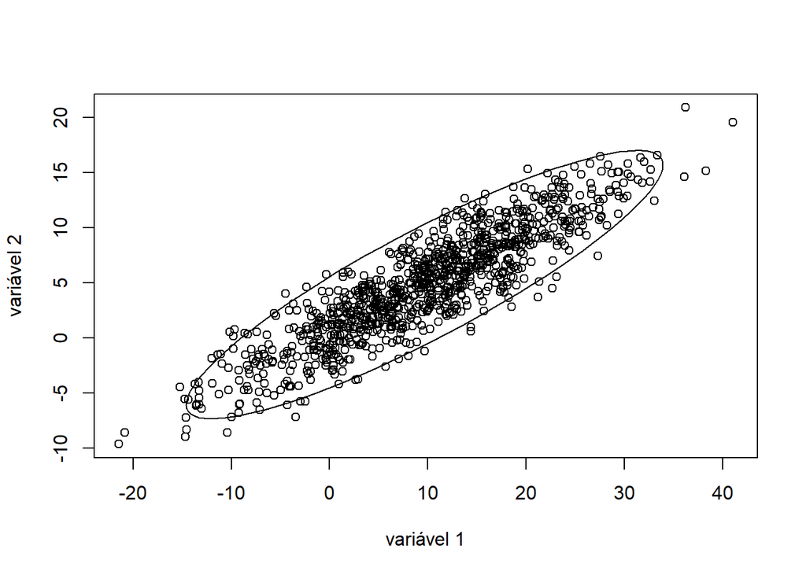

```r
# Dados simulados
n<-1000 # tamanho da amostra

# vetor de médias
mu <- c(10,5)

# matriz de covariâncias
rho<-0.9
var1<-100
var2<-25
Sigma<- rbind(cbind(var1,sqrt(var1*var2)*rho),cbind(sqrt(var1*var2)*rho,var2))

# gerando uma amostra
mx <- mvrnorm(n, mu, Sigma)
par(mfrow=c(1,1))
plot(mx[,1],mx[,2],xlab="variável 1", ylab="variável 2")

# estimativas de média, correlação e variâncias
ma <- apply(mx,2,mean)
rhoa <- cor(mx)[1,2]
vara1<-cov(mx)[1,1]
vara2<-cov(mx)[2,2]

# elipse com parâmetros estimados
lines(ellipse(rhoa, scale = c(sqrt(vara1), sqrt(vara2)),
              centre = rbind(ma[1], ma[2]), level = 0.95))
```

## Matriz de Dispersão

- *A matriz de dispersão mostra possíveis relações positivas entre as variáveis: (LP, CP), (CP,LP), (CS,CP), (CP,CS), (CS, LP), (LP,CS)*

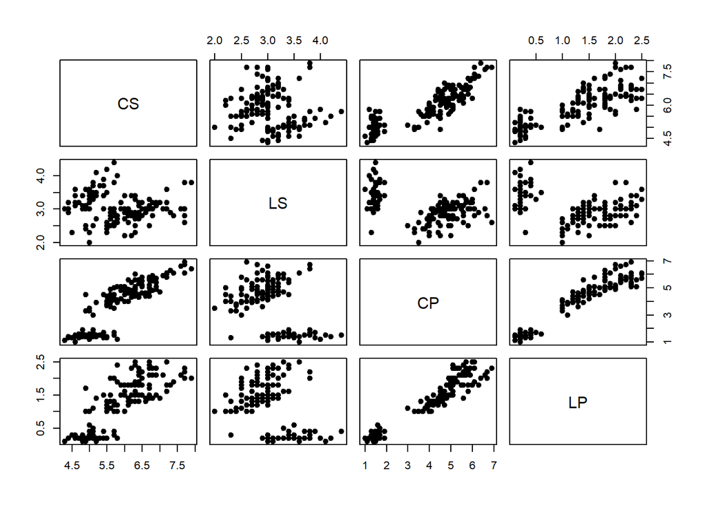

```r
# Dados da Íris de Fisher
iris<-as.matrix(iris[,1:4])

inames <- c("CS","LS","CP","LP")
colnames(iris)<-inames
par(mfrow=c(1,1))
pairs(iris,pch=19,cex.labels=1.4)
```

## Matriz de Correlação

- *O código abaixo gera uma matriz e gráfico de correlação das variáveis.*

*CS (Comprimento da Sépala):*

- *Tem uma correlação positiva forte com o Comprimento da Pétala (CP) (0.8718) e com a Largura da Pétala (LP) (0.8179, o que indica que, em geral, quanto maior o comprimento da sépala, maior tende a ser o comprimento da pétala.*
- *Tem uma correlação negativa fraca com a Largura da Sépala (LS) (-0.1176), o que indica uma relação leve de diminuição, mas não muito forte.*

*LS (Largura da Sépala):*

- *Tem uma correlação negativa moderada com o Comprimento da Pétala (CP) (-0.4284), o que sugere que, em geral, quando a largura da sépala aumenta, o comprimento da pétala tende a diminuir.*
- *Tem uma correlação negativa moderada com a Largura da Pétala (LP) (-0.3661), indicando uma relação semelhante à observada com o comprimento da pétala.*

*CP (Comprimento da Pétala):*

- *Tem uma correlação positiva forte com o Comprimento da Sépala (CS) (0.8718) e com a Largura da Pétala (LP) (0.9629), como mencionado anteriormente.*
- *A correlação positiva forte entre CP e LP sugere que, em geral, quanto maior o comprimento da pétala, maior tende a ser a largura da pétala.*

*LP (Largura da Pétala):*

- *Tem uma correlação positiva forte com o Comprimento da Sépala (CS) (0.8179) e com o Comprimento da Pétala (CP) (0.9629), como mencionado anteriormente.*
- *Assim como CP, a correlação positiva forte entre LP e CP sugere que, em geral, quanto maior a largura da pétala, maior tende a ser o comprimento da pétala.*

```r
# Matriz de correlações
cor(iris)
```

```
##            CS         LS         CP         LP
## CS  1.0000000 -0.1175698  0.8717538  0.8179411
## LS -0.1175698  1.0000000 -0.4284401 -0.3661259
## CP  0.8717538 -0.4284401  1.0000000  0.9628654
## LP  0.8179411 -0.3661259  0.9628654  1.0000000
```

```r
#xtable(cor(iris))
rho <-cor(iris) #lowerTriangle((cor(iris)))
xb <- apply(iris,2,mean)
s2<-cov(iris)
vara <-diag(s2)
nvar <- 4
```

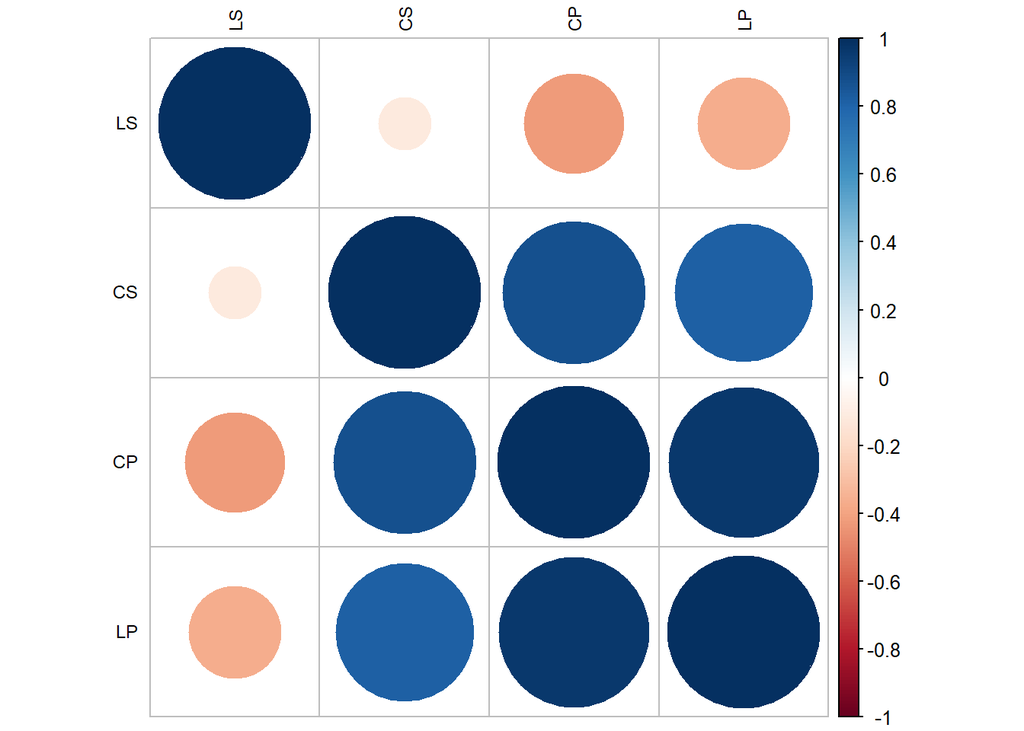

```r
# Gráfico de correlações

par(mfrow=c(1,1))
corrplot(cor(iris), order = "hclust", tl.col='black', tl.cex=.75)
```

## Boxplot

#### *Boxplot CS:*

- *Existe uma pequena dispersão nos dados, já que possui uma menor amplitude.*
- *Seu retangulo contém aproximadamente 50% dos valores do conjunto de dados,logo há uma possibilidade de sua distribuição ser simetrica*

#### *Boxplot LS:*

- *Existe uma pequena dispersão nos dados, já que possui uma menor amplitude.*
- *Seu retangulo contém aproximadamente 50% dos valores do conjunto de dados,logo há uma possibilidade de sua distribuição ser simetrica.*
- *Contém outliers já que possui pontos fora das “linhas”, ou seja, ultrapassando os valores máximos e minimos do boxplot.*

#### *Boxplot CP:*

- *Existe uma grande dispersão nos dados, já que possui uma maior amplitude.*
- *Seu retangulo não contém aproximadamente 50% dos valores do conjunto de dados,logo não há uma possibilidade de sua distribuição ser simetrica*

#### *Boxplot LP:*

- *Existe uma pequena dispersão nos dados, já que possui uma menor amplitude.*
- *Seu retangulo não contém aproximadamente 50% dos valores do conjunto de dados,logo não há uma possibilidade de sua distribuição ser simetrica*

*Sendo assim, pode-se observar que cada variável apresenta um nível de distribuição diferente de cada uma.*

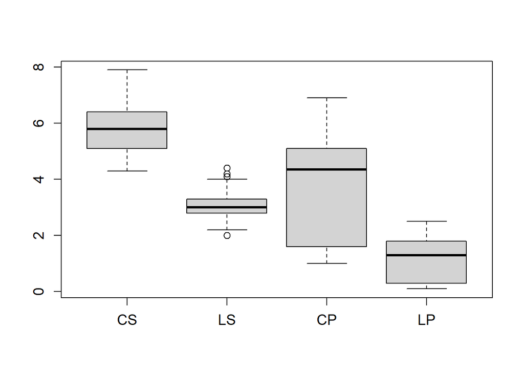

```r
# Boxplot

par(mfrow=c(1,1))
boxplot(iris,cex=1.2,cex.axis=1.2,cex.lab=1.2,names=inames)
```

## Teste de Kolmogorov-Smirnov

- *O código abaixo cálcula o p-valor usando o teste de Kolmogorov-Smirnov e em seguida plota histogramas para visualização da distribuição de frequência para cada variável*
- *Lembrando que o valor do p-valor alto (> 0,05) sugere que os dados não fornecem evidências suficientes para rejeitar a hipótse nula de que ele seguem uma distribuição normal.*
- *E o valor do p-valor baixo (< 0,05) sugere que os dados fornecem evidências suficientes para rejeitar a hipótse nula de que ele seguem uma distribuição normal.*
- *Diante dos testes a baixo de Kolmogorov-Smirnov feitos em cima de cada variável, é importante notar que para CP e LP, as evidências indicam que essas variáveis não seguem uma distribuição normal. Para CS e LS, os resultados não fornecem evidências conclusivas contra a normalidade.*
- *Os Histogramas também reforçam a afirmativa acima, em que os gráficos das variáveis CP e LP mostram uma distribuição bastante assimetrica em comparação as variáveis LS e CS.*

```r
par(mfrow=c(2,2))
for (i in 1:4) {
  ks_result <- ks.test(iris[,i], "pnorm", mean(iris[,i]), sd(iris[,i]))
  cat("Variável:", inames[i], "\n")
  cat("p-valor do teste de Kolmogorov-Smirnov:", ks_result$p.value, "\n\n")
}
```

```
## Variável: CS
## p-valor do teste de Kolmogorov-Smirnov: 0.1890886
```

```
## Variável: LS
## p-valor do teste de Kolmogorov-Smirnov: 0.07022646
```

```
## Variável: CP
## p-valor do teste de Kolmogorov-Smirnov: 1.531977e-05
```

```
## Variável: LP
## p-valor do teste de Kolmogorov-Smirnov: 0.0002565066
```

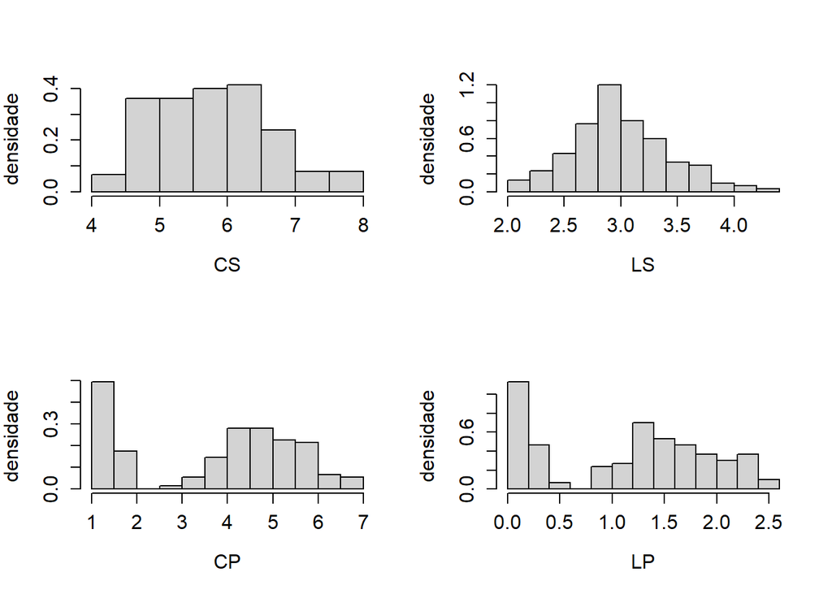

```r
# Histogramas

par(mfrow=c(2,2))
hist(iris[,1],xlab=inames[1],cex=1.2,cex.axis=1.2,cex.lab=1.2,
     main="",probability=TRUE,ylab="densidade")
hist(iris[,2],xlab=inames[2],cex=1.2,cex.axis=1.2,cex.lab=1.2,
     main="",probability=TRUE,ylab="densidade")
hist(iris[,3],xlab=inames[3],cex=1.2,cex.axis=1.2,cex.lab=1.2,
     main="",probability=TRUE,ylab="densidade")
hist(iris[,4],xlab=inames[4],cex=1.2,cex.axis=1.2,cex.lab=1.2,
     main="",probability=TRUE,ylab="densidade")
```

## Elipsóides de Confinaça

- *O código abaixo gera Elipsóides de confiança de 95% para cada correlação entre as variáveis do dataset.*
- *A forma das elipsoidse entre as variáveis (CP, CS), (LP, CS) e (LP, CP) estão alongadas em uma direção específica, isso pode indicar uma correlação positiva entre as variáveis nessa direção.*
- *A forma das elipsoidse entre as variáveis (LS, CS), (CP, LS) e (LP, LS) não estão alongadas em uma direção específica, isso pode indicar uma correlação negativa entre as variáveis.*
- *Os tamanhos dos eixos do elipsoide representam a incerteza associada às estimativas das variáveis observadas. Os eixos não indicam muita variabilidade e, portanto, menor incerteza nas estimativas.*

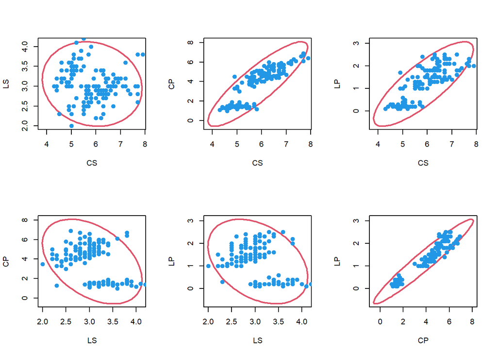

```r
# Elipsóides de Confiança

par(mfrow=c(2,3))
for (i in 1:(nvar-1)){
  for (j in (i+1):nvar){
    plot(ellipse(rho[i,j], scale = c(sqrt(vara[i]), sqrt(vara[j])),
                 centre = rbind(xb[i], xb[j]), level = 0.95),type="l",lwd=2,col=2,
         xlab=inames[i],ylab=inames[j])
    lines(iris[,i],iris[,j],pch=19,cex=1.2,cex.lab=1.2,cex.axis=1.2,type="p",col=4)
  }
}
```

## Gráfico Q-Q Plot

*O código a baixo cria um gráfico Q-Q PLot para cada variável, cada gráfico compara os quantis observados dos dados com os quantis teóricos de uma distribuição normal. Além disso, também foi cálculado o coeficiente de correlação Pearson entre os quantis teóricos e observados, esse coeficiente fornece uma medida da semelhança entre os dois conjuntos de quantis, onde valores proximos de 1 indicam uma boa concordância.*

- *Coeficiente de Correlação de Pearson para CS : 0.9891878*
- *Coeficiente de Correlação de Pearson para LS : 0.9925113*
- *Coeficiente de Correlação de Pearson para CP : 0.9378633*
- *Coeficiente de Correlação de Pearson para LP : 0.9517107*

*Diante dos gráficos, nota-se que os gráficos para as variáveis CS e LS existem uma pequena fuga de normaldade por assimetria. Enquanto os gráficos para CP e LP, mostra uma fuga de normalidade por assimetria mas com uma maior quantidade já que ficam mais dispersos no plano.*

```
## Coeficiente de Correlação de Pearson para CS : 0.9891878
```

```
## Coeficiente de Correlação de Pearson para LS : 0.9925113
```

```
## Coeficiente de Correlação de Pearson para CP : 0.9378633
```

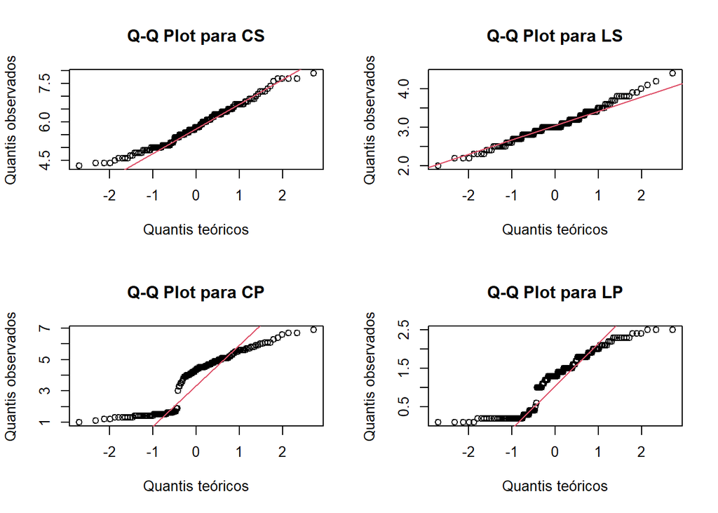

```
## Coeficiente de Correlação de Pearson para LP : 0.9517107
```

```r
# Gráfico Q-Q Plot

par(mfrow=c(2,2))
for (i in 1:4){
  qqnorm(iris[,i], main = paste('Q-Q Plot para', inames[i]), xlab = 'Quantis teóricos', ylab = 'Quantis observados')
  qqline(iris[,i], col = 2)

  qq_corr <- cor(qqnorm(iris[,i], plot.it = FALSE)$x, qqnorm(iris[,i], plot.it = FALSE)$y)
  cat('Coeficiente de Correlação de Pearson para', inames[i], ":", qq_corr, '\n\n')

}
```

## Gráfico Q-Q Plot para forma quadrática

- *Coeficiente de Correlação de Pearson para CS : 0.9804007*
- *Coeficiente de Correlação de Pearson para LS : 0.9801651*
- *Coeficiente de Correlação de Pearson para CP : 0.9556939*
- *Coeficiente de Correlação de Pearson para LP : 0.9481196*

```
## Coeficiente de Correlação de Pearson para CS : 0.9804007
```

```
## Coeficiente de Correlação de Pearson para LS : 0.9801651
```

```
## Coeficiente de Correlação de Pearson para CP : 0.9556939
```

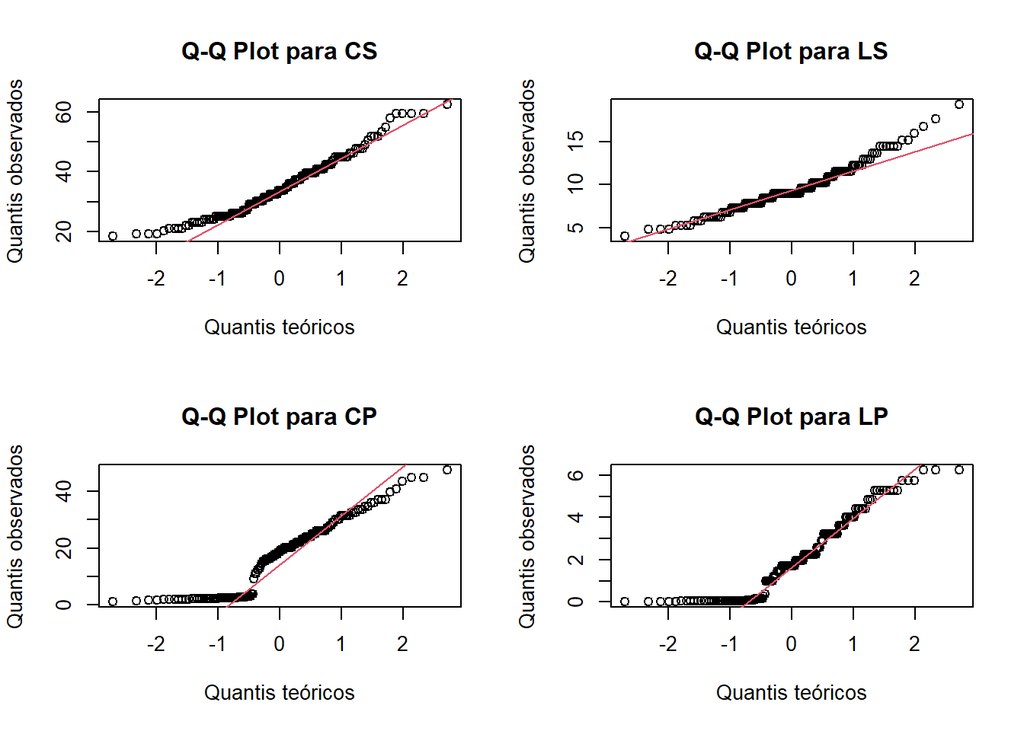

```
## Coeficiente de Correlação de Pearson para LP : 0.9481196
```

```r
# Gráfico Q-Q Plot para forma quadrática

par(mfrow=c(2,2))
for (i in 1:4){
  dados_quadraticos <- iris[,i]^2
  qqnorm(dados_quadraticos, main = paste('Q-Q Plot para', inames[i]), xlab = 'Quantis teóricos', ylab = 'Quantis observados')
  qqline(dados_quadraticos, col = 2)

  qq_corr <- cor(qqnorm(dados_quadraticos, plot.it = FALSE)$x, qqnorm(dados_quadraticos, plot.it = FALSE)$y)
  cat('Coeficiente de Correlação de Pearson para', inames[i], ":", qq_corr, '\n\n')

}
```